# Quantile Regression

Literature Review

Not Sure Group

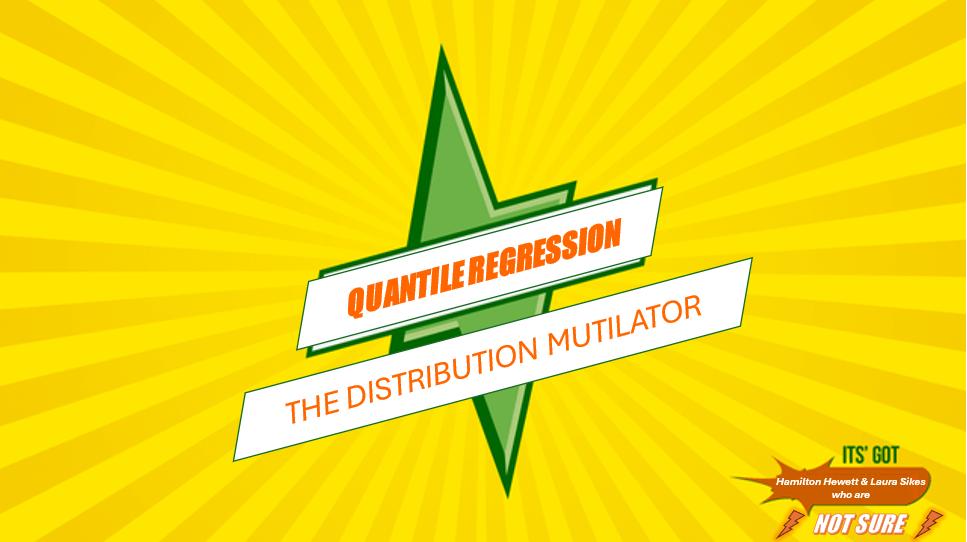

## Quantile Regression

- In 1978 Koenker and Bassett introduced ideas to the estimation of conditional quantile functions
- Quantile Regression vs. Linear Regression
- One Average vs. Several Averages
- One Group vs. Multiple Groups

Koenker, R., & Hallock, K. F. (2019). Quantile regression. *Nature Methods, 15*(4), 143–156. https://doi.org/10.1038/s41592-019-0406-y

## Quantile Regression 40 Years On

- No longer rely fully on Gaussian methods in some instances
- Quantile can show asymmetires and tail behavior
- Quantile Treatment Effect (QTE) is easily implemented as long as treatment is randomly assigned
- Interactions have significant effects on Quantiles
- Quantile provides a foundation for nonparametric structural models
- The old assumption was that all things empirical can be revelaed by their conditional means
- Time Series Models used to be dominated by Gaussian methods
- Information was lost using Gaussian when it came to the tail and asymmetries
- As data gets more complex and hetergeneity gains attention, Quantile methods become more favorable

Koenker, R. (2017). Quantile regression: 40 years on. *Annual Review of Economics. Volume 9*. 2017, Pp. 155-76, 9(1), 155–176. https://doi.org/10.1146/annurev-economics-063016-103651

## Thinking Beyond the Mean, Quantile Methods in Health Services Research

- Ordinary Least Squares and Logistic Regression assume coefficients remain constant
- These methods do not look at the group differences that are important
- Quantile is great for variables that ahave distinct categorical groups
- Quantile is not simply a regression estimated in quantiles
- Allows the relaxation of the common regression assumptions
- We try to minimize the weighted difference in Quantile Regression
- Quantile amplifies the ability to tell the difference in the upper and lower areas of the data
- Downside is that you cut your population everytime you add a quantile

Lê Cook, B., & Manning, W. G. (2013). Thinking beyond the mean: a practical guide for using quantile regression methods for health services research. *Shanghai Archives of Psychiatry, 25*(1), 55–59. https://doi.org/10.3969/j.issn.1002-0829.2013.01.011

## Quantile Regression - Opportunities and Challenges from a User’s Perspective

- Quantile is a stistical technique used to model quantiles within a regression framework
- Quantile is great for skewed datasets
- Some studies create their own “quantiles” in the requirements for a study group (have age cut offs)
- Quantile is difficult to visualize and understand an overall summary of a data set
- Less sensitive to outliers

Beyerlein, A. (2014). Quantile regression—opportunities and challenges from a user’s perspective. *American Journal of Epidemiology, 180*(3), 330–331. https://doi.org/10.1093/aje/kwu178

## No Crossing Single Index Quantile Regression Curve Estimation

- Thinking about Quantile formulas, they have to eventually cross
- This is problematic if you are estimating outside of your quantile you are observing and this is frowned upon
- The “curse of dimensionality” is real in Quantile
- It is intersting to see these crosses

Jiang, R., & Yu, K. (2023). No-crossing single-index quantile regression curve estimation. *Journal of Business & Economic Statistics, 41*(2), 309–320. https://doi.org/10.1080/07350015.2021.2013245

## Efficient Quantile Regression Analysis with Missing Observations

- Quantiles are great for having outliers because they are very resistant to the outliers
- When you have missing data, inverse probability weighing methods are great to use
- I will use .naomit

Chen, X., Wan, A. T. K., & Zhou, Y. (2015). Efficient quantile regression analysis with missing observations. *Journal of the American Statistical Association, 110*(510), 723–741. https://doi.org/10.1080/01621459.2014.928219

## Quantile regression: overview and selected applications

- The author provides an overview of quantile regression and illustrates two of its applications.
- Variables may enjoy unique relationships within different sections of a distribution, which can be more readily identified using quantile regression.
- The author notes this method is useful when working with non-Gaussian distributions

Buhai, S. (2005). Quantile regression: overview and selected applications. *Ad Astra, 4*(4), 1-17.

## Increasing sensitivity of results by using quantile regression analysis for exploring community resilience

- The authors used quantile regression to evaluate the relationships between community demographics and perceived resilience.
- The distribution was divided into percentiles and quartiles.
- A significant relationship was identified inside several quantiles that were not significant when using linear regression on the entire distribution.
- The authors note that quantile regression is a non-parametric method, meaning no assumptions are made about the sample size or the normality of the distribution.

Cohen, O., Bolotin, A., Lahad, M., Goldberg, A., & Aharonson-Daniel, L. (2016). Increasing sensitivity of results by using quantile regression analysis for exploring community resilience. *Ecological Indicators, 66*, 497-502.

## Quantile regression

- The equation for quantile regression is
  $$Q_Y(\tau \mid X) = X \beta(\tau)$$
- Q is the quantile function, τ represents the quantile of interest, Y is the response variable given the X predictor variable(s), and β is the regression coefficient.

Koenker, R. (2005). *Quantile regression*. Cambridge University Press.

## Quantile regression

- The authors explain quantile regression and contrast it against linear regression.
- Quantile regression allows the data scientist to learn about the predictor variables’ relationships with an outcome variable from a tiered perspective.
- Quantile regression is less affected by extreme values since it is not reliant on means.
- This approach is especially useful when the relationships of interest are primarily located in an upper or lower quartile.

Koenker, R. & Hallock, K. (2001). Quantile regression. Journal of Economic Perspectives, 15(4), 143-56.

## Goodness of fit and related inference processes for quantile regression

- The authors identified the absence of a suitable goodness-of-fit assessment for quantile regression.
- They developed a method with inspiration from R2, which is the coefficient of determination.
- Their methods are Δn(τ), Wn(τ), and Tn(τ)
- These new methods expanded the capacity for quantile regression inference.
- The theory behind these new methods is beyond the scope of this course.

Koenker, R. & Machado, J.A. (1999). Goodness of fit and related inference processes for quantile regression. *Journal of the American Statistical Association, 94*(48). 1296-310.

## Quantiles for counts

- The authors explored the use of quantile regression for count data.
- By incorporating artificial smoothness, the authors were able to make inferences about the conditional quartiles.
- This method is likely far outside the scope of our project but provides a reference point for defining quantile regression, its applications, and limitations.

Machado, J.A. & Santos Silva, J.M.C. (2005). Quantiles for counts. *Journal of the American Statistical Association, 400*(472), 1226-37. https://doi.org/10.1198/016214505000000330

## Use of quantile regression to determine the impact on total health care costs of surgical site infections following common ambulatory procedures

- The authors employed quantile regression in a retrospective cohort study using data from insurer claims.
- The intent was to identify factors affecting costs of infections following inpatient surgical procedures.
- Serious infections were categorized as those occurring in hospital or needing follow-up surgery, and were found to be the most costly.
- Quantile regression allowed the authors to focus on different factors associated with costs for the serious surgical infections located within that quantile.

Olsen, M.A., Tian, F., Wallace, A.E., Nickel, K.B., Warren, D.K., Fraser, V.J., … & Hamilton, B.H. (2017). Use of quantile regression to determine the impact on total health care costs of surgical site infections following common ambulatory procedures. *Annals of Surgery, 265*(2), 331-9. Doi:10.1097/SLA.0000000000001590

## Quantile regression and its applications: A primer for anesthesiologists

- The authors utilized QR to understand relationships between ventilator dependence and hospital length-of-stay.
- The authors suspected these relationships changed across different quantiles.
- The authors found stronger relationships between the predictor variables inside the upper quantiles of the length of stay outcome.

Staffa, S.J., Kohane, D.S., & Zurakowski, D. (2019). Quantile regression and its applications: A primer for anesthesiologists. *Anesthesia & Analgesia, 128*(4), 820-30. doi: 10.1213/ANE.0000000000004017

## Quantile regression: A short story on how and why

- The author utilized body mass index (BMI) data to illustrate the usefulness of quantile regression.
- The goal was to answer questions about the outer portions of the distribution, which in this case was boys with the highest BMI.
- Quantile regression afforded insight into how predictor variables can have stronger or weaker effects within different areas of the distribution.

Waldmann, E. (2018). Quantile regression: A short story on how and why. *Statistical Modelling, 18*(3-4), 203-18.

## Bibliography

Beyerlein, A. (2014). Quantile regression—opportunities and challenges from a user’s perspective. *American Journal of Epidemiology, 180*(3), 330–331. https://doi.org/10.1093/aje/kwu178

Buhai, S. (2005). Quantile regression: overview and selected applications. *Ad Astra, 4*(4), 1-17.

Chen, X., Wan, A. T. K., & Zhou, Y. (2015). Efficient quantile regression analysis with missing observations. *Journal of the American Statistical Association, 110*(510), 723–741. https://doi.org/10.1080/01621459.2014.928219

Cohen, O., Bolotin, A., Lahad, M., Goldberg, A., & Aharonson-Daniel, L. (2016). Increasing sensitivity of results by using quantile regression analysis for exploring community resilience. *Ecological Indicators, 66*, 497-502.

Jiang, R., & Yu, K. (2023). No-crossing single-index quantile regression curve estimation. *Journal of Business & Economic Statistics, 41*(2), 309–320. https://doi.org/10.1080/07350015.2021.2013245

Koenker, R. (2005). *Quantile regression*. Cambridge University Press.

## Bibliography

Koenker, R. & Hallock, K. (2001). Quantile regression. *Journal of Economic Perspectives, 15*(4), 143-56.

Koenker, R., & Hallock, K. F. (2019). Quantile regression. *Nature Methods, 15*(4), 143–156. https://doi.org/10.1038/s41592-019-0406-y

Koenker, R. & Machado, J.A. (1999). Goodness of fit and related inference processes for quantile regression. *Journal of the American Statistical Association, 94*(48). 1296-310.

Koenker, R. (2017). Quantile regression: 40 years on. *Annual Review of Economics. Volume 9*. 2017, Pp. 155-76, 9(1), 155–176. https://doi.org/10.1146/annurev-economics-063016-103651

Lê Cook, B., & Manning, W. G. (2013). Thinking beyond the mean: a practical guide for using quantile regression methods for health services research. *Shanghai Archives of Psychiatry, 25*(1), 55–59. https://doi.org/10.3969/j.issn.1002-0829.2013.01.011

Machado, J.A. & Santos Silva, J.M.C. (2005). Quantiles for counts. *Journal of the American Statistical Association, 400*(472), 1226-37. https://doi.org/10.1198/016214505000000330

## Bibliography

Olsen, M.A., Tian, F., Wallace, A.E., Nickel, K.B., Warren, D.K., Fraser, V.J., … & Hamilton, B.H. (2017). Use of quantile regression to determine the impact on total health care costs of surgical site infections following common ambulatory procedures. *Annals of Surgery, 265*(2), 331-9. Doi:10.1097/SLA.0000000000001590

Staffa, S.J., Kohane, D.S., & Zurakowski, D. (2019). Quantile regression and its applications: A primer for anesthesiologists. *Anesthesia & Analgesia, 128*(4), 820-30. doi: 10.1213/ANE.0000000000004017

Waldmann, E. (2018). Quantile regression: A short story on how and why. *Statistical Modelling, 18*(3-4), 203-18.